# Time Series Analysis with Python - I

### What is Time Series ?

#### Time series is a data set collected through time

```
Johnson & Johnson Quarterly Earning
Total Quarters :  84
```

|  | Year-Qtr | Time | Val |
| --- | --- | --- | --- |
| 0 | 1960-Q1 | 1960.00 | 0.71 |
| 1 | 1960-Q2 | 1960.25 | 0.63 |
| 2 | 1960-Q3 | 1960.50 | 0.85 |
| 3 | 1960-Q4 | 1960.75 | 0.44 |
| 4 | 1961-Q1 | 1961.00 | 0.61 |
| ... | ... | ... | ... |
| 79 | 1979-Q4 | 1979.75 | 9.99 |
| 80 | 1980-Q1 | 1980.00 | 16.20 |
| 81 | 1980-Q2 | 1980.25 | 14.67 |
| 82 | 1980-Q3 | 1980.50 | 16.02 |
| 83 | 1980-Q4 | 1980.75 | 11.61 |

84 rows × 3 columns

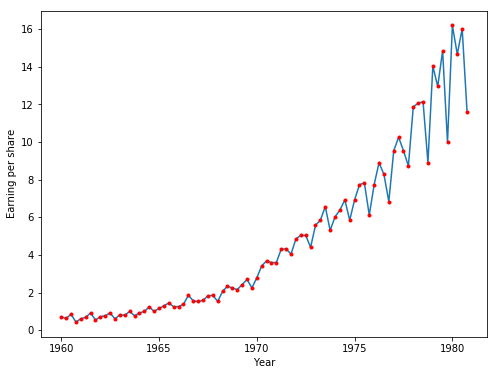

S/H

```python
import pandas as pd
import numpy as np
import matplotlib.pyplot as plt
import Toggle
pd.set_option('display.max_rows', 10)
df = pd.read_csv('JJ.csv')
print("Johnson & Johnson Quarterly Earning")
print('Total Quarters : ',len(df))
display(df)
plt.figure(figsize=(8,6))
plt.plot(df.Time.values, df.Val.values,marker='.',markerfacecolor='red', markeredgecolor='red')
plt.ylabel('Earning per share')
plt.xlabel('Year')
plt.show()
Toggle.hide_toggle()
```

```
Global Temperature
Total Length :  136
```

|  | Time | Val |
| --- | --- | --- |
| 0 | 1880 | -0.20 |
| 1 | 1881 | -0.11 |
| 2 | 1882 | -0.10 |
| 3 | 1883 | -0.20 |
| 4 | 1884 | -0.28 |
| ... | ... | ... |
| 131 | 2011 | 0.60 |
| 132 | 2012 | 0.63 |
| 133 | 2013 | 0.66 |
| 134 | 2014 | 0.75 |
| 135 | 2015 | 0.87 |

136 rows × 2 columns

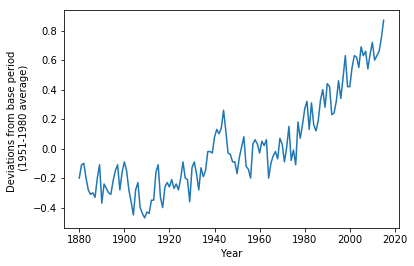

S/H

```python
import pandas as pd
import numpy as np
import matplotlib.pyplot as plt
import Toggle
pd.set_option('display.max_rows', 10)
df = pd.read_csv('globtemp.csv')
print("Global Temperature")
print('Total Length : ',len(df))
display(df)
plt.plot(df.Time.values, df.Val.values)
plt.xlabel("Year")
plt.ylabel("Deviations from base period \n (1951-1980 average)")
plt.show()
Toggle.hide_toggle()
```

```
Monthly pneumonia and influenza deaths per 10,000 people
Total Months :  132
```

|  | Year-Month | Time | Val |
| --- | --- | --- | --- |
| 0 | Jan-1968 | 1968.000000 | 0.811372 |
| 1 | Feb-1968 | 1968.083333 | 0.445829 |
| 2 | Mar-1968 | 1968.166667 | 0.341599 |
| 3 | Apr-1968 | 1968.250000 | 0.277424 |
| 4 | May-1968 | 1968.333333 | 0.248496 |
| ... | ... | ... | ... |
| 127 | Aug-1978 | 1978.583333 | 0.185368 |
| 128 | Sep-1978 | 1978.666667 | 0.194387 |
| 129 | Oct-1978 | 1978.750000 | 0.229073 |
| 130 | Nov-1978 | 1978.833333 | 0.225355 |
| 131 | Dec-1978 | 1978.916667 | 0.256941 |

132 rows × 3 columns

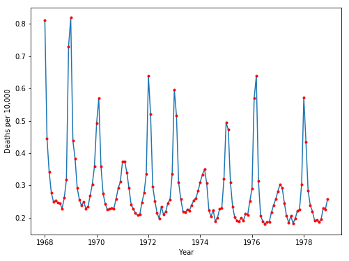

S/H

```python
df = pd.read_csv('flu.csv')
print("Monthly pneumonia and influenza deaths per 10,000 people")
print('Total Months : ',len(df))
display(df)
plt.figure(figsize=(8,6))
plt.plot(df.Time.values, df.Val.values,marker='.',markerfacecolor='red', markeredgecolor='red')
plt.ylabel('Deaths per 10,000')
plt.xlabel('Year')
plt.show()
Toggle.hide_toggle()
```

```
The magnitude of a star taken at midnight for 600 consecutive days
```

|  | Time | Val |
| --- | --- | --- |
| 0 | 1 | 25 |
| 1 | 2 | 28 |
| 2 | 3 | 31 |
| 3 | 4 | 32 |
| 4 | 5 | 33 |
| ... | ... | ... |
| 595 | 596 | 2 |
| 596 | 597 | 2 |
| 597 | 598 | 2 |
| 598 | 599 | 4 |
| 599 | 600 | 5 |

600 rows × 2 columns

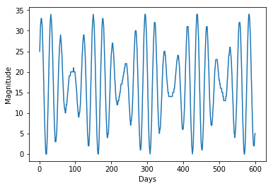

S/H

```python
df = pd.read_csv('star.csv')
print('The magnitude of a star taken at midnight for 600 consecutive days')
display(df)
plt.plot(df.Time,df.Val)
plt.xlabel('Days')
plt.ylabel('Magnitude')
plt.show()
Toggle.hide_toggle()
```

### Weak Stationary Process

In a weak stationary time series, there is

1. No systematic change in mean (no trend)
2. No systematic change in variance
3. No periodic variations

The properties of one section of a data are much like the properties of the other sections of the data  
For an non-stationary time series, we will do some transformations to get stationary time series

## Random Process (or Stochastic Process)

A discrete stochastic process is a family of random variables structured as a sequence (finite or infinite) and has a discrete time index, denoted $X_t$  
So, $X_1,X_2,X_3,.........X_N$ is a random process where each of $X_t$ is a random variable  
We can obtain properties of each $X_t$ if have the luxury of observing multiple trajectories of a random process  
For example the below table shows multiple trajectories of a single random process $X_1,X_2,X_3,.........X_7$  
For each random variable of the sequence we can find distribution if we have large number of trajectories

```python
import pandas as pd
import numpy as np
from numpy.random import seed
from numpy.random import rand
import Toggle
rpdf = pd.DataFrame(columns=["X\u2081","X\u2082","X\u2083","X\u2084","X\u2085","X\u2086","X\u2087"],dtype=np.float32)
for i in range(5):
    rpdf.loc[len(rpdf)] =  np.round(rand(7),3)
display(rpdf)
Toggle.hide_toggle()
#df = pd.DataFrame(columns = column_names)
```

|  | X₁ | X₂ | X₃ | X₄ | X₅ | X₆ | X₇ |
| --- | --- | --- | --- | --- | --- | --- | --- |
| 0 | 0.600 | 0.505 | 0.646 | 0.909 | 0.308 | 0.754 | 0.590 |
| 1 | 0.241 | 0.249 | 0.351 | 0.018 | 0.858 | 0.324 | 0.841 |
| 2 | 0.648 | 0.663 | 0.243 | 0.748 | 0.131 | 0.168 | 0.171 |
| 3 | 0.377 | 0.051 | 0.820 | 0.612 | 0.872 | 0.949 | 0.806 |
| 4 | 0.304 | 0.888 | 0.761 | 0.141 | 0.278 | 0.605 | 0.314 |

S/H

### Auto-covariance

Given a stochastic process, the autocovariance is a function that gives the covariance of the process with itself at pairs of time points.

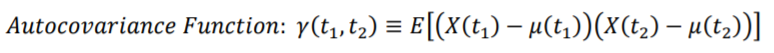

where $t_1$ and $t_2$ are two moments in time  
Here, $t_2-t_1=\tau$ is termed as 'lag'  
In the above example we can find $covar(X_2,X_5)$ which is actually 'auto-covariance' between $2^{nd}$ and $5^{th}$ time step of the random process.

### Auto-correlation

Similar to auto-covariance function we can define auto-correlation function as correlation of the process with itself at pairs of time points.  
Autocorrelation Function, $ \rho(t_1,t_2) = \frac{E[(X(t_1)-\mu(t_1))(X(t_2)-\mu(t_2))]}{\sigma_{t_1} \sigma_{t_2}} = \frac{\gamma(t_1,t_2)}{\sigma_{t_1} \sigma_{t_2}}$

A stochastic process is a rather complicated thing. To fully specify its structure we would need to know the joint distribution of the full set of random variables. So, we must know all possible trajectories.

#### But we generally have one sequence !!!!

We usually just have one sequentially observed data set and must infer the properties of the generating process from this single trajectory.

### Stationarity (strictly stationary)

We can work using a single trajectory if process is stationary (strictly stationary)  
$\implies$

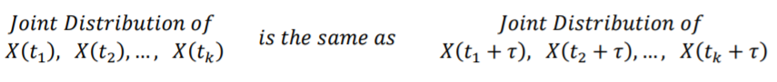

#### But strict stationarity is very strong and hard to determine so we go for weak stationarity which is enough to use same results.

### Weak Stationarity

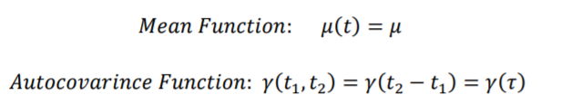

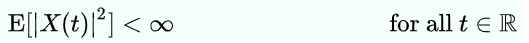

With these, putting 𝜏=0  
𝛾(0) = constant = $E[(X_t-\mu)(X_t-\mu)]$ = Variance  
Also, $\rho(0) = 1$  
If weak stationarity is assumed we get enough values (or pairs) from a single a trajectory to estimate variance, auto-covariance and auto-correlation  
Let's say $x_1,x_2,x_3,x_4,x_5,x_6,x_7,x_8,x_9.....x_N$ is a single trajectory of random process  
Then below defined $c_k$ is approximation of 𝛾(k)

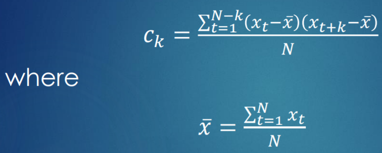

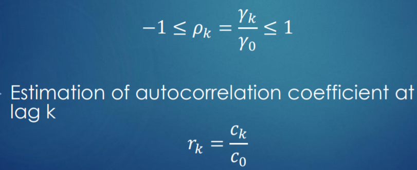

#### Plot of autocorrelation for a time series for different lags is called correlogram

#### Purely Random Process (is a weakly stationary process)

$X_t = Z_t$  
$X_t$ = Value at time t  
$Z_t$ = White noise $(Normal(\mu,\sigma^2)).$At each time the $Z_t$ is a random variable from a normal distribution. So, there will be no correlation between $Z_t$'s (or $X_t$'s) at different t's

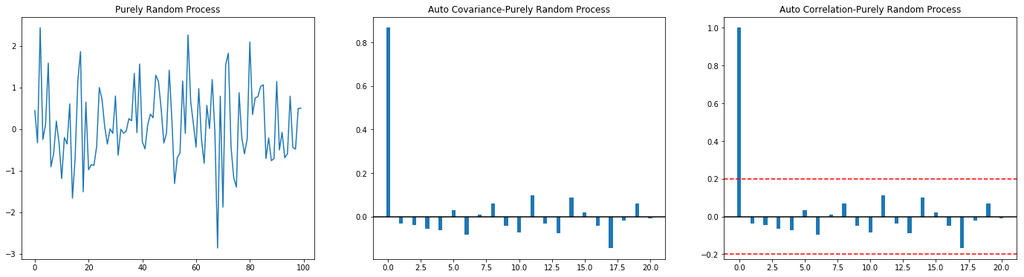

S/H

```python
import numpy as np
import pandas as pd
import matplotlib.pyplot as plt
import statsmodels.tsa.stattools as ts
import Toggle
np.random.seed(5)
x = np.random.normal(loc=0.0,scale=1.0,size=100)
plt.figure(figsize=(24,6))
plt.subplot(1,3,1)
plt.title("Purely Random Process")
plt.plot(x)

plt.subplot(1,3,2)
acovf_x = ts.acovf(x,fft=False,adjusted=False,nlag=20)
plt.bar(x=np.arange(len(acovf_x)),height=acovf_x,width=0.3)
plt.axhline(y=0,color='black')
plt.title("Auto Covariance-Purely Random Process")

plt.subplot(1,3,3)
acorf_x = ts.acf(x,fft=False,adjusted=False,nlags=20)
plt.bar(x=np.arange(len(acorf_x)),height=acorf_x,width=0.3)
plt.axhline(y=0,color='black')
plt.axhline(y=0.2,color='red',linestyle='--')
plt.axhline(y=-0.2,color='red',linestyle='--')
plt.title("Auto Correlation-Purely Random Process")
#plt.plot(x)
plt.show()
Toggle.hide_toggle()
```

### Random Walk (is not a weakly stationary process)

$X_t = X_{t-1} + Z_t$  
We can prove by expanding $X_t$ into sum of consecutive $Z_t$'s that $E[X_t]$ and $var(X_t)$ is dependent on $t$.

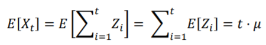

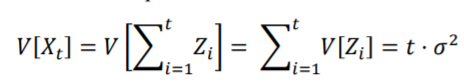

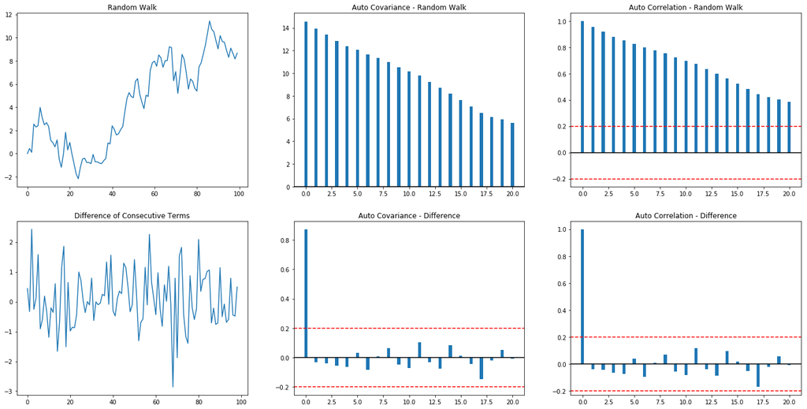

S/H

```python
x = []
x.append(0)
np.random.seed(5)
for i in range(1,100):
    z = np.random.normal(size=1)[0]
    x.append(x[i-1] + z)

plt.figure(figsize=(24,12))
plt.subplot(2,3,1)
plt.title("Random Walk")
plt.plot(x)

plt.subplot(2,3,2)
acovf_x = ts.acovf(x,fft=False,adjusted=False,nlag=20)
plt.bar(x=np.arange(len(acovf_x)),height=acovf_x,width=0.3)
plt.axhline(y=0,color='black')
plt.title("Auto Covariance - Random Walk")

plt.subplot(2,3,3)
acorf_x = ts.acf(x,fft=False,adjusted=False,nlags=20)
plt.bar(x=np.arange(len(acorf_x)),height=acorf_x,width=0.3)
plt.axhline(y=0,color='black')
plt.axhline(y=0.2,color='red',linestyle='--')
plt.axhline(y=-0.2,color='red',linestyle='--')
plt.title("Auto Correlation - Random Walk")


plt.subplot(2,3,4)
dx = [(x[i]-x[i-1]) for i in range(1,len(x))]
plt.plot(dx)
plt.title("Difference of Consecutive Terms")

plt.subplot(2,3,5)
acovf_dx = ts.acovf(dx,fft=False,adjusted=False,nlag=20)
plt.bar(x=np.arange(len(acovf_dx)),height=acovf_dx,width=0.3)
plt.axhline(y=0,color='black')
plt.axhline(y=0.2,color='red',linestyle='--')
plt.axhline(y=-0.2,color='red',linestyle='--')
plt.title("Auto Covariance - Difference")

plt.subplot(2,3,6)
acorf_dx = ts.acf(dx,fft=False,adjusted=False,nlags=20)
plt.bar(x=np.arange(len(acorf_dx)),height=acorf_dx,width=0.3)
plt.axhline(y=0,color='black')
plt.axhline(y=0.2,color='red',linestyle='--')
plt.axhline(y=-0.2,color='red',linestyle='--')
plt.title("Auto Correlation - Difference")
plt.show()

Toggle.hide_toggle()
```

### Moving Average Process (is a weakly stationary process)

Moving average process of order q, MA(q)  
$X_t =Z_t + \beta_1Z_{t-1} + \beta_2Z_{t-2} + \beta_3Z_{t-3} + ..... + \beta_qZ_{t-q}$  
𝑍𝑖 are i.i.d. & 𝑍𝑖 ~ 𝑁𝑜𝑟𝑚𝑎𝑙 (𝜇, $𝜎_2$)  
ACF for MA(q) process cuts off a lag q  
**Why ?**

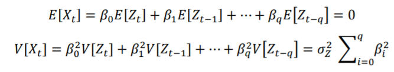

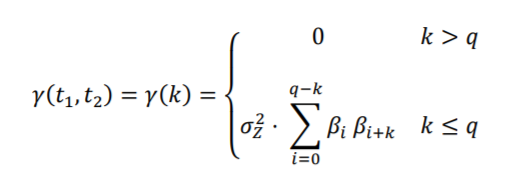

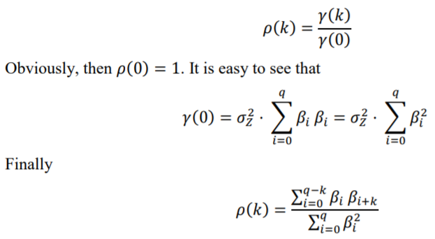

##### Simulating a MA (2) Process

Below we simulate a MA(2) process  
$X_t =Z_t + \beta_1Z_{t-1} + \beta_2Z_{t-2}$  
Keeping  
$\beta_1 = 0.5$  
$\beta_2 = 0.5$  
And we observe how auto-correlation coefficient become negligible after lag of 2

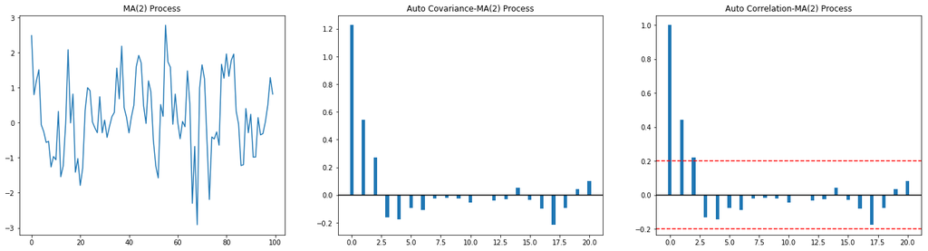

S/H

```python
import pandas as pd
import numpy as np
import matplotlib.pyplot as plt
import Toggle
import statsmodels.tsa.stattools as ts

np.random.seed(5)
Z = np.random.normal(size=102)
a = 0.5
b = 0.5
x = [(Z[i]+a*Z[i-1]+b*Z[i-2]) for i in range(2,len(Z))]

plt.figure(figsize=(24,6))
plt.subplot(1,3,1)
plt.title("MA(2) Process")
plt.plot(x)

plt.subplot(1,3,2)
acovf_x = ts.acovf(x,fft=False,adjusted=False,nlag=20)
plt.bar(x=np.arange(len(acovf_x)),height=acovf_x,width=0.3)
plt.axhline(y=0,color='black')
plt.title("Auto Covariance-MA(2) Process")

plt.subplot(1,3,3)
acorf_x = ts.acf(x,fft=False,adjusted=False,nlags=20)
plt.bar(x=np.arange(len(acorf_x)),height=acorf_x,width=0.3)
plt.axhline(y=0,color='black')
plt.axhline(y=0.2,color='red',linestyle='--')
plt.axhline(y=-0.2,color='red',linestyle='--')
plt.title("Auto Correlation-MA(2) Process")
#plt.plot(x)
plt.show()
Toggle.hide_toggle()
```